CSC2701 Project update

# SolarPower Rangers

Estimated solar output, hour by hour across Canada.

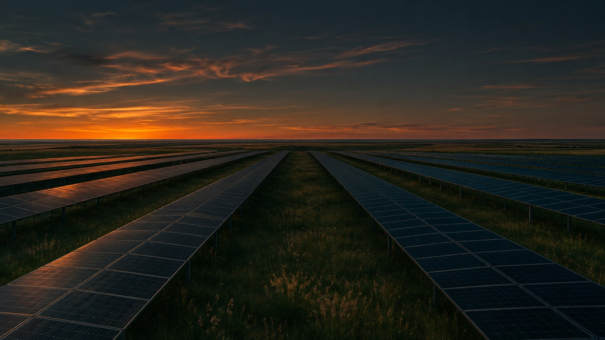

## A forecast you can compare

Where and when is solar output expected to peak?

**164**

### Canadian grid cells

One sampled land point per cell.

**24**

### Hours in one window

Every location shares the same forecast period.

The map compares total energy in kWh. Each cell shows hourly power in kW and its peak in local time.

## Explore the dashboard

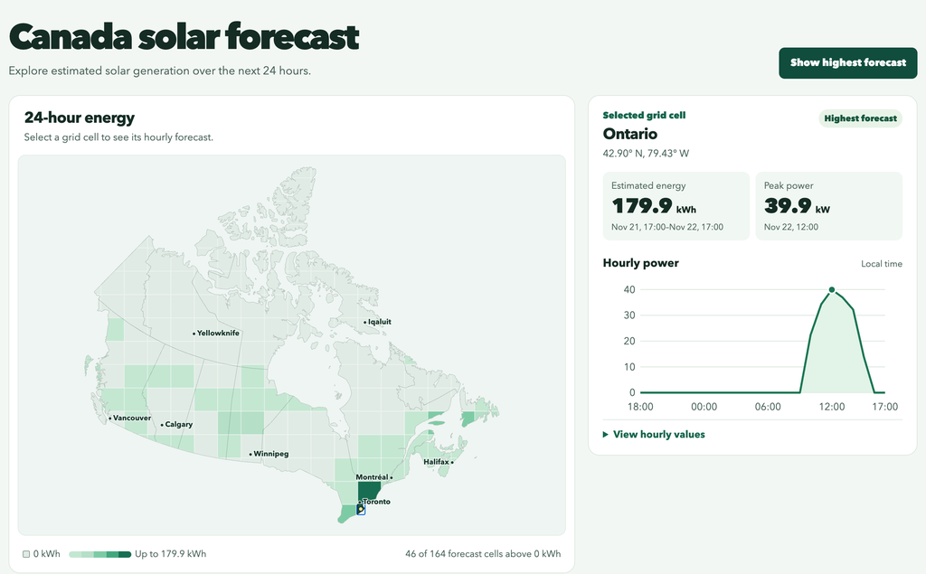

Forecast snapshot from November 21, 2026

**Select a grid cell**  
Read its total energy, hourly curve and local peak.

**Show highest forecast**  
Jump to the cell with the highest 24-hour energy estimate.

[Open the dashboard ↗](https://solarpowerrangers-ui-wme4w5h72a-ew.a.run.app/)

## One day in an Ontario grid cell

[figure not shown]

Forecast issued November 21, 2026. Hours are shown in Eastern time.

**179.9 kWh**

Estimated energy over 24 hours

**39.9 kW**

Peak power at noon on November 22

## Forecast architecture

Weather data

### Open-Meteo

Hourly irradiance, temperature and cloud cover

Cloud Run container

### FastAPI forecast service

1. Align weather to the 164-cell Canada grid.
2. Estimate hourly power with the bundled XGBoost model.
3. Sum the hourly estimates to get 24-hour energy.

Browser

### Canada dashboard

Energy map and hourly power chart

The browser reads the forecast from `GET /forecast/canada`.

## How changes reach Cloud Run

GitHub Actions builds the UI, API and hourly model into one Docker image.

### Build & test

1. Check the frontend and run a container smoke test.

### Publish

2. Push the tested image to Artifact Registry.

### Verify

3. Check the candidate revision against live weather.

### Route traffic

4. Send public traffic to the verified revision.

Branch pushes and pull requests run the build and test. A push to `main` runs the full release.

## Two tests, different weather inputs

In GitHub Actions

### Fixed weather

Run the container without network access and check model startup and forecast output for all 164 cells.

On the Cloud Run candidate

### Live weather

Check that the candidate can fetch weather and return a fresh forecast with 24 hourly values and consistent energy totals.

Both checks verify that the dashboard and model serve valid responses.

## Verify first, then switch traffic

While testing

Current revision**100%**

Candidate revision**0%**

→

After the live check passes

Previous revision**0%**

Verified revision**100%**

[First deployment from main passed ↗](https://github.com/UofT-CSC2701-2026/SolarPowerRangers/actions/runs/44953561107) November 21, 2026

## Validating the forecast

Forecast accuracy across Canada is still unvalidated.

**Forecast inputs**

Use archived weather forecasts to measure how forecast errors affect output estimates.

**Cold-weather performance**

Compare estimates with measured solar generation at Canadian sites, including during cold periods.

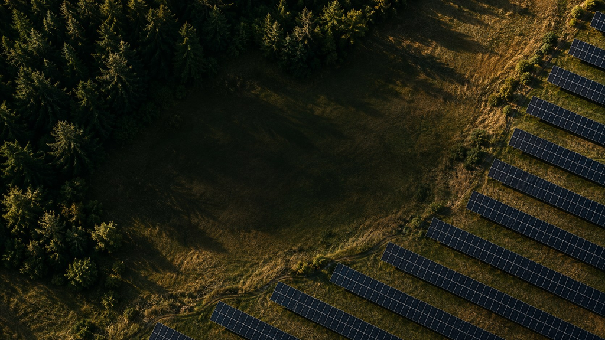

## Project contributors

- Nishil Kapadia
- Shivam Chanan
- Varun Patel
- Alex Lewis

[Open the live dashboard ↗](https://solarpowerrangers-ui-wme4w5h72a-ew.a.run.app/)

[figure not shown]

Scan to open